https://xuanshay.github.io

# Project: Popular Video Game Trend

Group Memebers: Yuxuan Zhang, Haowen Weng

The project aims to dig into the market of video games. The project investigares tendencies and conclusions about the video game industries. And also the project estimates the lifetime of popular video games.

## Contents:

- Datasets
- Purpose and Questions
- Initialization
- Data Generalization, Extraction, Transfrom, and Load
- Analyzing datasets and getting into the problems

## Datasets:

- Video Games Sales
  - Downloaded from https://www.kaggle.com/gregorut/videogamesales
  - The dataset contains a list of video games with sales greater than 100,000 copies. The release year of the games are between 1980 and 2020
- Steam database
  - Scraped from https://store.steampowered.com/stats/
  - The website introduced games with most steam users. It includes both current players and the peak of the day.
- Previous Steam Games Ranking
  - Downloaded from https://www.kaggle.com/michau96/popularity-of-games-on-steam/version/6
  - Th data shows the top trending games with most players of previous years

## Purpose and Questions:

- Game production companies' preformance in 21th century.
- Players' taste in different region
- The lifttime of a game

## Initialization

```python
!pip install beautifulsoup4
!pip install requests
!pip install pandas
!pip install numpy
!pip install html5lib
!pip3 install lxml

!pip install html5lib
```

[output not shown]

```python
!pip install html5lib
```

```python
#%matplotlib inline
import numpy as np
import pandas as pd
import requests
import numpy
import lxml
from bs4 import BeautifulSoup
import re
import html5lib
```

## Data Generalization, Extraction, Transfrom, and Load

### Data Set 1: Video Games Slaes

Our dataset is generated by a scrape of [VGChartz](https://www.vgchartz.com/). It contains a list of video games with sales greater than 100,000 copies in worldwide.

Notice: 1.) Sales are in millions. 2.)Data collected from 2017

```python
vgs = pd.read_csv("vgsales.csv")
vgs.head(30)
```

|  | Rank | Name | Platform | Year | Genre | Publisher | NA_Sales | EU_Sales | JP_Sales | Other_Sales | Global_Sales |
| --- | --- | --- | --- | --- | --- | --- | --- | --- | --- | --- | --- |
| 0 | 1 | Wii Sports | Wii | 2006.0 | Sports | Nintendo | 41.49 | 29.02 | 3.77 | 8.46 | 82.74 |
| 1 | 2 | Super Mario Bros. | NES | 1985.0 | Platform | Nintendo | 29.08 | 3.58 | 6.81 | 0.77 | 40.24 |
| 2 | 3 | Mario Kart Wii | Wii | 2008.0 | Racing | Nintendo | 15.85 | 12.88 | 3.79 | 3.31 | 35.82 |
| 3 | 4 | Wii Sports Resort | Wii | 2009.0 | Sports | Nintendo | 15.75 | 11.01 | 3.28 | 2.96 | 33.00 |
| 4 | 5 | Pokemon Red/Pokemon Blue | GB | 1996.0 | Role-Playing | Nintendo | 11.27 | 8.89 | 10.22 | 1.00 | 31.37 |
| 5 | 6 | Tetris | GB | 1989.0 | Puzzle | Nintendo | 23.20 | 2.26 | 4.22 | 0.58 | 30.26 |
| 6 | 7 | New Super Mario Bros. | DS | 2006.0 | Platform | Nintendo | 11.38 | 9.23 | 6.50 | 2.90 | 30.01 |
| 7 | 8 | Wii Play | Wii | 2006.0 | Misc | Nintendo | 14.03 | 9.20 | 2.93 | 2.85 | 29.02 |
| 8 | 9 | New Super Mario Bros. Wii | Wii | 2009.0 | Platform | Nintendo | 14.59 | 7.06 | 4.70 | 2.26 | 28.62 |
| 9 | 10 | Duck Hunt | NES | 1984.0 | Shooter | Nintendo | 26.93 | 0.63 | 0.28 | 0.47 | 28.31 |
| 10 | 11 | Nintendogs | DS | 2005.0 | Simulation | Nintendo | 9.07 | 11.00 | 1.93 | 2.75 | 24.76 |
| 11 | 12 | Mario Kart DS | DS | 2005.0 | Racing | Nintendo | 9.81 | 7.57 | 4.13 | 1.92 | 23.42 |
| 12 | 13 | Pokemon Gold/Pokemon Silver | GB | 1999.0 | Role-Playing | Nintendo | 9.00 | 6.18 | 7.20 | 0.71 | 23.10 |
| 13 | 14 | Wii Fit | Wii | 2007.0 | Sports | Nintendo | 8.94 | 8.03 | 3.60 | 2.15 | 22.72 |
| 14 | 15 | Wii Fit Plus | Wii | 2009.0 | Sports | Nintendo | 9.09 | 8.59 | 2.53 | 1.79 | 22.00 |
| 15 | 16 | Kinect Adventures! | X360 | 2010.0 | Misc | Microsoft Game Studios | 14.97 | 4.94 | 0.24 | 1.67 | 21.82 |
| 16 | 17 | Grand Theft Auto V | PS3 | 2013.0 | Action | Take-Two Interactive | 7.01 | 9.27 | 0.97 | 4.14 | 21.40 |
| 17 | 18 | Grand Theft Auto: San Andreas | PS2 | 2004.0 | Action | Take-Two Interactive | 9.43 | 0.40 | 0.41 | 10.57 | 20.81 |
| 18 | 19 | Super Mario World | SNES | 1990.0 | Platform | Nintendo | 12.78 | 3.75 | 3.54 | 0.55 | 20.61 |
| 19 | 20 | Brain Age: Train Your Brain in Minutes a Day | DS | 2005.0 | Misc | Nintendo | 4.75 | 9.26 | 4.16 | 2.05 | 20.22 |
| 20 | 21 | Pokemon Diamond/Pokemon Pearl | DS | 2006.0 | Role-Playing | Nintendo | 6.42 | 4.52 | 6.04 | 1.37 | 18.36 |
| 21 | 22 | Super Mario Land | GB | 1989.0 | Platform | Nintendo | 10.83 | 2.71 | 4.18 | 0.42 | 18.14 |
| 22 | 23 | Super Mario Bros. 3 | NES | 1988.0 | Platform | Nintendo | 9.54 | 3.44 | 3.84 | 0.46 | 17.28 |
| 23 | 24 | Grand Theft Auto V | X360 | 2013.0 | Action | Take-Two Interactive | 9.63 | 5.31 | 0.06 | 1.38 | 16.38 |
| 24 | 25 | Grand Theft Auto: Vice City | PS2 | 2002.0 | Action | Take-Two Interactive | 8.41 | 5.49 | 0.47 | 1.78 | 16.15 |
| 25 | 26 | Pokemon Ruby/Pokemon Sapphire | GBA | 2002.0 | Role-Playing | Nintendo | 6.06 | 3.90 | 5.38 | 0.50 | 15.85 |
| 26 | 27 | Pokemon Black/Pokemon White | DS | 2010.0 | Role-Playing | Nintendo | 5.57 | 3.28 | 5.65 | 0.82 | 15.32 |
| 27 | 28 | Brain Age 2: More Training in Minutes a Day | DS | 2005.0 | Puzzle | Nintendo | 3.44 | 5.36 | 5.32 | 1.18 | 15.30 |
| 28 | 29 | Gran Turismo 3: A-Spec | PS2 | 2001.0 | Racing | Sony Computer Entertainment | 6.85 | 5.09 | 1.87 | 1.16 | 14.98 |
| 29 | 30 | Call of Duty: Modern Warfare 3 | X360 | 2011.0 | Shooter | Activision | 9.03 | 4.28 | 0.13 | 1.32 | 14.76 |

### Data Set 2: Steam database

First, we scrap and generate the dataframe using several pandas functions

```python
header = {'User-Agent': 'Mozilla/5.0 (Macintosh; Intel Mac OS X 10_10_1) AppleWebKit/537.36 (KHTML, like Gecko) Chrome/39.0.2171.95 Safari/537.36'}
response = requests.get('https://store.steampowered.com/stats/',headers=header)
resource = response.text
```

```python
souped_resource = BeautifulSoup(resource,"html.parser")
prettify_resource = BeautifulSoup.prettify(souped_resource)
soup = BeautifulSoup(prettify_resource)
table_found = soup.find("div",{'id' : "detailStats"})
```

```python
table_found = re.sub("display: none;",'',str(table_found))
```

```python
table = pd.read_html(str(table_found))
```

```python
df_steam = pd.DataFrame(table[0])
```

```python
df_steam
```

|  | 0 | 1 | 2 | 3 | 4 |
| --- | --- | --- | --- | --- | --- |
| 0 | Current Players | Peak Today | NaN | Game | NaN |
| 1 | NaN | NaN | NaN | NaN | NaN |
| 2 | 747380 | 811481 | NaN | Counter-Strike: Global Offensive | NaN |
| 3 | 534547 | 632470 | NaN | Dota 2 | NaN |
| 4 | 205001 | 205001 | NaN | New World | NaN |
| ... | ... | ... | ... | ... | ... |
| 97 | 7417 | 7668 | NaN | STAR WARS™: The Old Republic™ | NaN |
| 98 | 7186 | 7287 | NaN | BeamNG.drive | NaN |
| 99 | 6976 | 9365 | NaN | Forza Horizon 4 | NaN |
| 100 | 6965 | 6965 | NaN | Assetto Corsa | NaN |
| 101 | 6788 | 6788 | NaN | Space Engineers | NaN |

102 rows × 5 columns

```python
df_steam = df_steam.loc[2:]
```

```python
#drop blank columns
df_steam =df_steam.drop(columns = 2)
df_steam =df_steam.drop(columns = 4)
```

```python
#Set the columns index
df_steam.columns=['Current Players','Peak Today','Game']
```

```python
#set the name of the games throughtout all database the same
df_steam['Game'][5] = 'PLAYERUNKNOWN\'S BATTLEGROUNDS'
```

```python
df_steam
```

|  | Current Players | Peak Today | Game |
| --- | --- | --- | --- |
| 2 | 747380 | 811481 | Counter-Strike: Global Offensive |
| 3 | 534547 | 632470 | Dota 2 |
| 4 | 205001 | 205001 | New World |
| 5 | 117074 | 226370 | PLAYERUNKNOWN'S BATTLEGROUNDS |
| 6 | 101094 | 101094 | Team Fortress 2 |
| ... | ... | ... | ... |
| 97 | 7417 | 7668 | STAR WARS™: The Old Republic™ |
| 98 | 7186 | 7287 | BeamNG.drive |
| 99 | 6976 | 9365 | Forza Horizon 4 |
| 100 | 6965 | 6965 | Assetto Corsa |
| 101 | 6788 | 6788 | Space Engineers |

100 rows × 3 columns

### Data Set 3: Previous players count for games on steam

```python
# Read the csv file
df_previous_user = pd.read_csv("SteamCharts.csv",encoding='latin1')
df_previous_user
```

|  | gamename | year | month | avg | gain | peak | avg_peak_perc |
| --- | --- | --- | --- | --- | --- | --- | --- |
| 0 | Counter-Strike: Global Offensive | 2021 | February | 741013.24 | -2196.42 | 1123485 | 65.9567% |
| 1 | Counter-Strike: Global Offensive | 2021 | January | 743209.66 | 25405.91 | 1124553 | 66.0893% |
| 2 | Counter-Strike: Global Offensive | 2020 | December | 717803.75 | 49049.17 | 1164396 | 61.646% |
| 3 | Counter-Strike: Global Offensive | 2020 | November | 668754.58 | 55087.89 | 1037464 | 64.4605% |
| 4 | Counter-Strike: Global Offensive | 2020 | October | 613666.69 | 6816.37 | 943876 | 65.0156% |
| ... | ... | ... | ... | ... | ... | ... | ... |
| 83784 | Steel Division: Normandy 44 | 2017 | July | 421.60 | -485.13 | 987 | 42.7153% |
| 83785 | Steel Division: Normandy 44 | 2017 | June | 906.74 | -231.92 | 2584 | 35.0906% |
| 83786 | Steel Division: Normandy 44 | 2017 | May | 1138.66 | 415.61 | 4606 | 24.7212% |
| 83787 | Steel Division: Normandy 44 | 2017 | April | 723.05 | 720.21 | 1911 | 37.8362% |
| 83788 | Steel Division: Normandy 44 | 2017 | March | 2.84 | NaN | 14 | 20.2857% |

83789 rows × 7 columns

## Analyzing datasets and getting into the problems

### 1. The struggle between producers

To find out the main stream tendency of gaming industries, we better first take a look on publishing companies, Let's overview the performance of all the manufacturers since 2000.

```python
recent_game = vgs.loc[vgs["Year"]>2000]
recent_game.head()
```

|  | Rank | Name | Platform | Year | Genre | Publisher | NA_Sales | EU_Sales | JP_Sales | Other_Sales | Global_Sales |
| --- | --- | --- | --- | --- | --- | --- | --- | --- | --- | --- | --- |
| 0 | 1 | Wii Sports | Wii | 2006.0 | Sports | Nintendo | 41.49 | 29.02 | 3.77 | 8.46 | 82.74 |
| 2 | 3 | Mario Kart Wii | Wii | 2008.0 | Racing | Nintendo | 15.85 | 12.88 | 3.79 | 3.31 | 35.82 |
| 3 | 4 | Wii Sports Resort | Wii | 2009.0 | Sports | Nintendo | 15.75 | 11.01 | 3.28 | 2.96 | 33.00 |
| 6 | 7 | New Super Mario Bros. | DS | 2006.0 | Platform | Nintendo | 11.38 | 9.23 | 6.50 | 2.90 | 30.01 |
| 7 | 8 | Wii Play | Wii | 2006.0 | Misc | Nintendo | 14.03 | 9.20 | 2.93 | 2.85 | 29.02 |

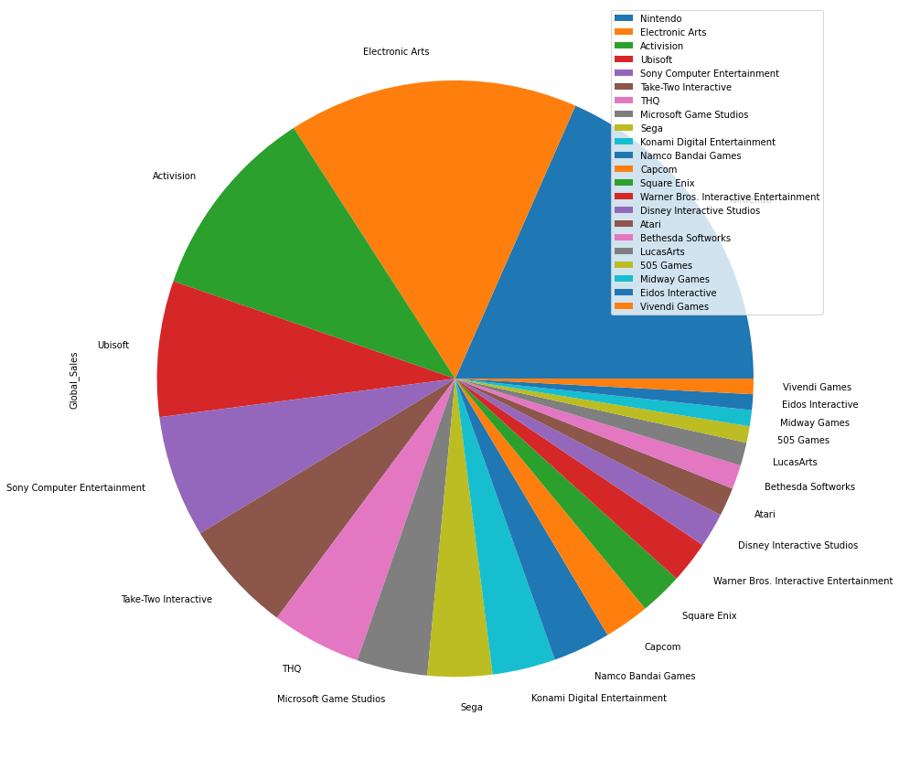

```python
companies = recent_game.groupby("Publisher").sum().sort_values("Global_Sales",ascending=False)
del companies["Year"]
del companies["Rank"]
top_tier = companies.loc[companies["Global_Sales"]>50]
top_tier.plot.pie(y="Global_Sales",figsize=(15, 15))
```

However, this chart conclude all sales from 2000 till now, to investigate the performance macroscopically, we want to know the flowing of sales of game producing over periods.

```python
q1 = recent_game.loc[recent_game["Year"]<2004]

q2 = recent_game.loc[recent_game["Year"]<2008]
q2 = q2.loc[recent_game["Year"]>2003]

q3 = recent_game.loc[recent_game["Year"]>2007]
q3 = q3.loc[recent_game["Year"]<2012]

q4 = recent_game.loc[recent_game["Year"]>2012]
```

```python
company_q1 = q1.groupby("Publisher").sum().sort_values("Global_Sales",ascending=False).loc[:,["Global_Sales"]]
company_q2 = q2.groupby("Publisher").sum().sort_values("Global_Sales",ascending=False).loc[:,["Global_Sales"]]
company_q3 = q3.groupby("Publisher").sum().sort_values("Global_Sales",ascending=False).loc[:,["Global_Sales"]]
company_q4 = q4.groupby("Publisher").sum().sort_values("Global_Sales",ascending=False).loc[:,["Global_Sales"]]
```

```python
top_10_q1 = company_q1.iloc[:10]
top_10_q2 = company_q2.iloc[:10]
top_10_q3 = company_q3.iloc[:10]
top_10_q4 = company_q4.iloc[:10]
```

```python
top_10_q1
```

| Publisher | Global_Sales |
| --- | --- |
| Electronic Arts | 187.96 |
| Nintendo | 131.82 |
| Sony Computer Entertainment | 93.46 |
| THQ | 78.51 |
| Activision | 65.91 |
| Take-Two Interactive | 51.29 |
| Konami Digital Entertainment | 48.28 |
| Atari | 46.34 |
| Ubisoft | 38.09 |
| Sega | 31.43 |

```python
top_10_q2
```

| Publisher | Global_Sales |
| --- | --- |
| Nintendo | 497.91 |
| Electronic Arts | 264.08 |
| Activision | 155.59 |
| Sony Computer Entertainment | 132.89 |
| THQ | 109.15 |
| Ubisoft | 97.76 |
| Take-Two Interactive | 90.80 |
| Konami Digital Entertainment | 66.93 |
| Sega | 63.02 |
| Microsoft Game Studios | 55.45 |

```python
top_10_q3
```

| Publisher | Global_Sales |
| --- | --- |
| Nintendo | 332.71 |
| Electronic Arts | 323.95 |
| Activision | 260.60 |
| Ubisoft | 195.10 |
| Sony Computer Entertainment | 125.46 |
| Take-Two Interactive | 119.16 |
| THQ | 110.15 |
| Sega | 101.79 |
| Microsoft Game Studios | 101.36 |
| Konami Digital Entertainment | 72.50 |

```python
top_10_q4
```

| Publisher | Global_Sales |
| --- | --- |
| Electronic Arts | 157.39 |
| Nintendo | 131.99 |
| Activision | 127.27 |
| Take-Two Interactive | 100.59 |
| Ubisoft | 92.18 |
| Warner Bros. Interactive Entertainment | 64.04 |
| Sony Computer Entertainment | 49.20 |
| Namco Bandai Games | 41.65 |
| Microsoft Game Studios | 38.07 |
| Square Enix | 36.60 |

```python
#visualize (to be finished)
company_q1["period"]="2000-2003"
company_q2["period"]="2004-2007"
company_q3["period"]="2008-2011"
company_q4["period"]="2012-2016"
top_10_over_time = company_q1.iloc[:10]
top_10_over_time=top_10_over_time.append(company_q2.iloc[:10])
top_10_over_time=top_10_over_time.append(company_q3.iloc[:10])
top_10_over_time=top_10_over_time.append(company_q4.iloc[:10])
```

### 2.The taste between players

Question2: Is there a difference in consumer's preference throughout different regions?

Let's first look at each different region

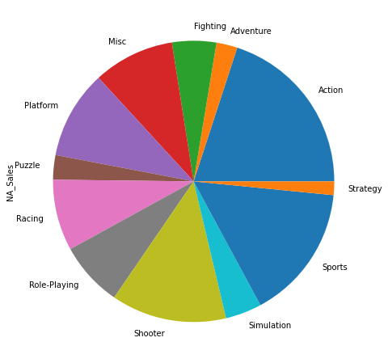

```python
#NA
NA_genre= vgs.groupby("Genre")["NA_Sales"].sum()
NA_genre.plot.pie(figsize=(8, 8))
```

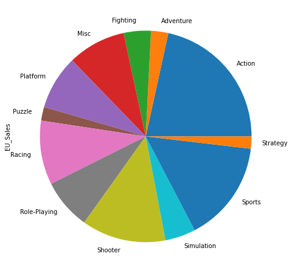

```python
#EU
EU_genre = vgs.groupby("Genre")["EU_Sales"].sum()
EU_genre.plot.pie(figsize=(8, 8))
```

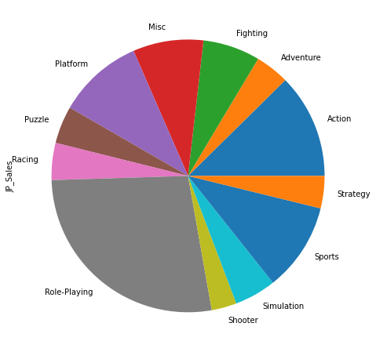

```python
#JP
JP_genre = vgs.groupby("Genre")["JP_Sales"].sum()
JP_genre.plot.pie(figsize=(8, 8))
```

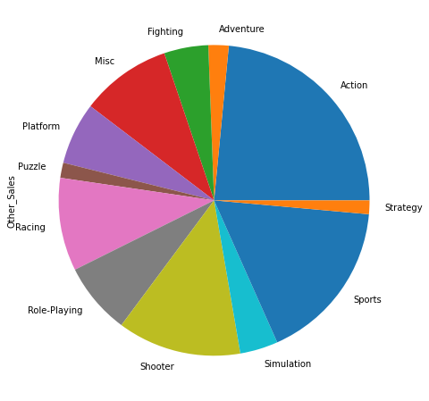

```python
#Other region
OT_genre = vgs.groupby("Genre")["Other_Sales"].sum()
OT_genre.plot.pie(figsize=(8, 8))
```

After seeing every region's distribution, we have to compare the proportion of each type of games to see if a there's a dominated game genre around here

| Genre | NA_Sales | EU_Sales | JP_Sales | Other_Sales | World_Average |
| --- | --- | --- | --- | --- | --- |
| Action | 0.199827 | 0.215683 | 0.123894 | 0.234886 | 0.193572 |
| Sports | 0.155556 | 0.154819 | 0.104855 | 0.169188 | 0.146105 |
| Role-Playing | 0.074501 | 0.077260 | 0.272893 | 0.074723 | 0.124844 |
| Shooter | 0.132622 | 0.128699 | 0.029651 | 0.128725 | 0.104924 |
| Misc | 0.093386 | 0.088730 | 0.083469 | 0.094416 | 0.090000 |
| Platform | 0.101765 | 0.082835 | 0.101292 | 0.064669 | 0.087640 |
| Racing | 0.081817 | 0.097936 | 0.043911 | 0.096860 | 0.080131 |
| Fighting | 0.050897 | 0.041625 | 0.067660 | 0.045979 | 0.051540 |
| Simulation | 0.041728 | 0.046579 | 0.049341 | 0.039511 | 0.044290 |
| Adventure | 0.024084 | 0.026346 | 0.040332 | 0.021072 | 0.027959 |
| Puzzle | 0.028177 | 0.020862 | 0.044391 | 0.015732 | 0.027290 |
| Strategy | 0.015639 | 0.018627 | 0.038311 | 0.014240 | 0.021704 |

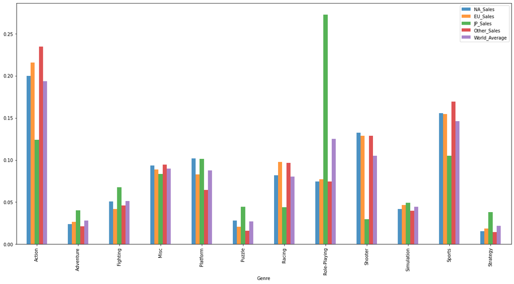

```python
NA_genre_por = NA_genre/NA_genre.sum()
EU_genre_por = EU_genre/EU_genre.sum()
JP_genre_por = JP_genre/JP_genre.sum()
OT_genre_por = OT_genre/OT_genre.sum()
world_genre = NA_genre_por.to_frame().join(EU_genre_por).join(JP_genre_por).join(OT_genre_por)
world_genre["World_Average"]=(world_genre["NA_Sales"]+world_genre["EU_Sales"]+world_genre["JP_Sales"]+world_genre["Other_Sales"])/4
world_genre.plot.bar(alpha=0.8,figsize = (20,10))
world_genre.sort_values("World_Average",ascending=False)
```

That's very clear that what people in different region prefers.

Some conclusion:

1) Action Game(0.194) seems to be generally the most favored genre all around, second is sports(0.146) and third is role-playing(0.125)

3) Most minority types of game: Adventure(0.0280), Puzzle(0.0273), Strategy(0.0217). Reason perhaps will be the hardcore playing style.

2) Japaness people are indeed obsessed with the Role-playing, this might lead by the well-development of JRPG

### 3. The lifetime of a game

#### Find out the data we need from different datasets

##### A little formatting stuff for the scraped dataframe

```python
df_steam_now = df_steam
```

```python
df_steam_now = df_steam_now.reset_index(drop = True)
```

```python
# Add two columns:Year and Ranking for the data we scraped from steam(which is the present ranking)
i = 0
df_steam_now['Year'] = 2021
df_steam_now['Ranking'] = np.nan
for i in range(len(df_steam_now['Ranking'])):
  df_steam_now['Ranking'][i] = int(i+1)
```

```python
df_steam_now
```

|  | Current Players | Peak Today | Game | Year | Ranking |
| --- | --- | --- | --- | --- | --- |
| 0 | 747380 | 811481 | Counter-Strike: Global Offensive | 2021 | 1.0 |
| 1 | 534547 | 632470 | Dota 2 | 2021 | 2.0 |
| 2 | 205001 | 205001 | New World | 2021 | 3.0 |
| 3 | 117074 | 226370 | PLAYERUNKNOWN'S BATTLEGROUNDS | 2021 | 4.0 |
| 4 | 101094 | 101094 | Team Fortress 2 | 2021 | 5.0 |
| ... | ... | ... | ... | ... | ... |
| 95 | 7417 | 7668 | STAR WARS™: The Old Republic™ | 2021 | 96.0 |
| 96 | 7186 | 7287 | BeamNG.drive | 2021 | 97.0 |
| 97 | 6976 | 9365 | Forza Horizon 4 | 2021 | 98.0 |
| 98 | 6965 | 6965 | Assetto Corsa | 2021 | 99.0 |
| 99 | 6788 | 6788 | Space Engineers | 2021 | 100.0 |

100 rows × 5 columns

```python
# drop Current Players and Peak Today as we don't need to compare these data later on
top_game = df_steam_now
del top_game['Current Players']
del top_game['Peak Today']

#set the index of top_game the same as df_previous_user
top_game.rename({'Game': 'gamename', 'Year': 'year'}, axis=1, inplace=True)
top_game
```

|  | gamename | year | Ranking |
| --- | --- | --- | --- |
| 0 | Counter-Strike: Global Offensive | 2021 | 1.0 |
| 1 | Dota 2 | 2021 | 2.0 |
| 2 | New World | 2021 | 3.0 |
| 3 | PLAYERUNKNOWN'S BATTLEGROUNDS | 2021 | 4.0 |
| 4 | Team Fortress 2 | 2021 | 5.0 |
| ... | ... | ... | ... |
| 95 | STAR WARS™: The Old Republic™ | 2021 | 96.0 |
| 96 | BeamNG.drive | 2021 | 97.0 |
| 97 | Forza Horizon 4 | 2021 | 98.0 |
| 98 | Assetto Corsa | 2021 | 99.0 |
| 99 | Space Engineers | 2021 | 100.0 |

100 rows × 3 columns

### Collect data from all database

For previous ranking, we are ranking them based on the average players.

#### 2020 Ranking

```python
data_2020 = df_previous_user.loc[(df_previous_user['year']==2020) & (df_previous_user['month']=="November ")]

#delete unrelated columns
del data_2020['gain']
del data_2020['peak']
del data_2020['avg_peak_perc']
del data_2020['month']

#sort by average players
data_2020 = data_2020.sort_values(by=['avg'],ascending= False)

#find top 100
data_2020 = data_2020[:100]

#reset index
data_2020 = data_2020.reset_index(drop= True)

#set ranking
i = 0
data_2020['Ranking'] = np.nan
for i in range(len(data_2020['Ranking'])):
  data_2020['Ranking'][i] = int(i+1)

# delete average players
del data_2020['avg']
```

```python
#append to top_game
top_game = top_game.append(data_2020)
```

#### 2019 Ranking

```python
data_2019 = df_previous_user.loc[(df_previous_user['year']==2019) & (df_previous_user['month']=="November ")]

#delete unrelated columns
del data_2019['gain']
del data_2019['peak']
del data_2019['avg_peak_perc']
del data_2019['month']

#sort by average players
data_2019 = data_2019.sort_values(by=['avg'],ascending= False)

#find top 100
data_2019 = data_2019[:100]

#reset index
data_2019 = data_2019.reset_index(drop= True)

#set ranking
i = 0
data_2019['Ranking'] = np.nan
for i in range(len(data_2019['Ranking'])):
  data_2019['Ranking'][i] = int(i+1)

# delete average players
del data_2019['avg']
```

```python
#append to top_game
top_game = top_game.append(data_2019)
```

#### 2018 Ranking

```python
data_2018 = df_previous_user.loc[(df_previous_user['year']==2018) & (df_previous_user['month']=="November ")]

#delete unrelated columns
del data_2018['gain']
del data_2018['peak']
del data_2018['avg_peak_perc']
del data_2018['month']

#sort by average players
data_2018 = data_2018.sort_values(by=['avg'],ascending= False)

#find top 100
data_2018 = data_2018[:100]

#reset index
data_2018 = data_2018.reset_index(drop= True)

#set ranking
i = 0
data_2018['Ranking'] = np.nan
for i in range(len(data_2018['Ranking'])):
  data_2018['Ranking'][i] = int(i+1)

# delete average players
del data_2018['avg']
data_2018
```

|  | gamename | year | Ranking |
| --- | --- | --- | --- |
| 0 | Dota 2 | 2018 | 1.0 |
| 1 | PLAYERUNKNOWN'S BATTLEGROUNDS | 2018 | 2.0 |
| 2 | Counter-Strike: Global Offensive | 2018 | 3.0 |
| 3 | Warframe | 2018 | 4.0 |
| 4 | Tom Clancy's Rainbow Six Siege | 2018 | 5.0 |
| ... | ... | ... | ... |
| 95 | Sins of a Solar Empire: Rebellion | 2018 | 96.0 |
| 96 | Z1 Battle Royale | 2018 | 97.0 |
| 97 | Space Engineers | 2018 | 98.0 |
| 98 | DISTRAINT: Deluxe Edition | 2018 | 99.0 |
| 99 | Crossout | 2018 | 100.0 |

100 rows × 3 columns

```python
#append to top_game
top_game = top_game.append(data_2018)
top_game = top_game.reset_index(drop = True)
```

#### 2017 Ranking

```python
data_2017 = df_previous_user.loc[(df_previous_user['year']==2017) & (df_previous_user['month']=="November ")]

#delete unrelated columns
del data_2017['gain']
del data_2017['peak']
del data_2017['avg_peak_perc']
del data_2017['month']

#sort by average players
data_2017 = data_2017.sort_values(by=['avg'],ascending= False)

#find top 100
data_2017 = data_2017[:100]

#reset index
data_2017 = data_2017.reset_index(drop= True)

#set ranking
i = 0
data_2017['Ranking'] = np.nan
for i in range(len(data_2017['Ranking'])):
  data_2017['Ranking'][i] = int(i+1)

# delete average players
del data_2017['avg']
```

```python
top_game = top_game.append(data_2017)
top_game = top_game.reset_index(drop = True)
```

#### 2016 Ranking

```python
data_2016 = df_previous_user.loc[(df_previous_user['year']==2016) & (df_previous_user['month']=="November ")]

#delete unrelated columns
del data_2016['gain']
del data_2016['peak']
del data_2016['avg_peak_perc']
del data_2016['month']

#sort by average players
data_2016 = data_2016.sort_values(by=['avg'],ascending= False)

#find top 100
data_2016 = data_2016[:100]

#reset index
data_2016 = data_2016.reset_index(drop= True)

#set ranking
i = 0
data_2016['Ranking'] = np.nan
for i in range(len(data_2016['Ranking'])):
  data_2016['Ranking'][i] = int(i+1)

# delete average players
del data_2016['avg']
```

```python
top_game = top_game.append(data_2016)
top_game = top_game.reset_index(drop = True)
```

```python
top_game
```

|  | gamename | year | Ranking |
| --- | --- | --- | --- |
| 0 | Counter-Strike: Global Offensive | 2021 | 1.0 |
| 1 | Dota 2 | 2021 | 2.0 |
| 2 | New World | 2021 | 3.0 |
| 3 | PLAYERUNKNOWN'S BATTLEGROUNDS | 2021 | 4.0 |
| 4 | Team Fortress 2 | 2021 | 5.0 |
| ... | ... | ... | ... |
| 595 | Space Engineers | 2016 | 96.0 |
| 596 | Microsoft Flight Simulator X: Steam Edition | 2016 | 97.0 |
| 597 | Dying Light | 2016 | 98.0 |
| 598 | Counter-Strike Nexon: Studio | 2016 | 99.0 |
| 599 | Total War: SHOGUN 2 | 2016 | 100.0 |

600 rows × 3 columns

### Generating a bump chart from top_game

We found the way to generate a bumpp chart in pandas from the website: https://stackoverflow.com/questions/68095438/how-to-make-a-bump-chart

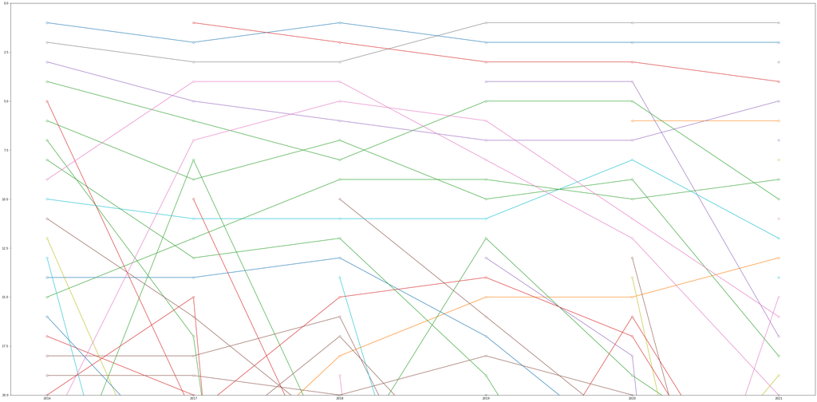

```python
#making a bump chart
import matplotlib.pyplot as plt
plt.rcParams["figure.figsize"] = (50, 25)
for i, j in top_game.groupby("gamename"):
    plt.plot( "year", "Ranking","o-", data=j, mfc="w")
plt.ylim(0, 20)
plt.gca().invert_yaxis()
#the graph still needs improvement for better visualization
```